# Risk Factor Analysis

## Outcome Variable

**Outcome Variable:** ever_swasted

## Predictor Variables

**Intervention Variable:** gagebrth

**Adjustment Set:**

- arm
- sex
- W_mage
- meducyrs
- feducyrs
- hhwealth_quart
- W_nchldlt5
- brthmon
- W_parity
- impsan
- delta_W_mage
- delta_meducyrs
- delta_feducyrs
- delta_hhwealth_quart
- delta_W_nchldlt5
- delta_brthmon
- delta_W_parity
- delta_impsan

## Stratifying Variables

The analysis was stratified on these variable(s):

- agecat
- studyid
- country

## Data Summary

| agecat | studyid | country | gagebrth | ever_swasted | n_cell | n |
| --- | --- | --- | --- | --- | --- | --- |
| 0-24 months (no birth wast) | ki1000108-CMC-V-BCS-2002 | INDIA | Full or late term | 0 | 183 | 348 |
| 0-24 months (no birth wast) | ki1000108-CMC-V-BCS-2002 | INDIA | Full or late term | 1 | 30 | 348 |
| 0-24 months (no birth wast) | ki1000108-CMC-V-BCS-2002 | INDIA | Preterm | 0 | 42 | 348 |
| 0-24 months (no birth wast) | ki1000108-CMC-V-BCS-2002 | INDIA | Preterm | 1 | 10 | 348 |
| 0-24 months (no birth wast) | ki1000108-CMC-V-BCS-2002 | INDIA | Early term | 0 | 71 | 348 |
| 0-24 months (no birth wast) | ki1000108-CMC-V-BCS-2002 | INDIA | Early term | 1 | 12 | 348 |
| 0-24 months (no birth wast) | ki1000108-IRC | INDIA | Full or late term | 0 | 206 | 389 |
| 0-24 months (no birth wast) | ki1000108-IRC | INDIA | Full or late term | 1 | 43 | 389 |
| 0-24 months (no birth wast) | ki1000108-IRC | INDIA | Preterm | 0 | 34 | 389 |
| 0-24 months (no birth wast) | ki1000108-IRC | INDIA | Preterm | 1 | 8 | 389 |
| 0-24 months (no birth wast) | ki1000108-IRC | INDIA | Early term | 0 | 74 | 389 |
| 0-24 months (no birth wast) | ki1000108-IRC | INDIA | Early term | 1 | 24 | 389 |
| 0-24 months (no birth wast) | ki1000109-EE | PAKISTAN | Full or late term | 0 | 16 | 377 |
| 0-24 months (no birth wast) | ki1000109-EE | PAKISTAN | Full or late term | 1 | 0 | 377 |
| 0-24 months (no birth wast) | ki1000109-EE | PAKISTAN | Preterm | 0 | 240 | 377 |
| 0-24 months (no birth wast) | ki1000109-EE | PAKISTAN | Preterm | 1 | 61 | 377 |
| 0-24 months (no birth wast) | ki1000109-EE | PAKISTAN | Early term | 0 | 55 | 377 |
| 0-24 months (no birth wast) | ki1000109-EE | PAKISTAN | Early term | 1 | 5 | 377 |
| 0-24 months (no birth wast) | ki1017093c-NIH-Crypto | BANGLADESH | Full or late term | 0 | 165 | 754 |
| 0-24 months (no birth wast) | ki1017093c-NIH-Crypto | BANGLADESH | Full or late term | 1 | 3 | 754 |
| 0-24 months (no birth wast) | ki1017093c-NIH-Crypto | BANGLADESH | Preterm | 0 | 250 | 754 |
| 0-24 months (no birth wast) | ki1017093c-NIH-Crypto | BANGLADESH | Preterm | 1 | 11 | 754 |
| 0-24 months (no birth wast) | ki1017093c-NIH-Crypto | BANGLADESH | Early term | 0 | 319 | 754 |
| 0-24 months (no birth wast) | ki1017093c-NIH-Crypto | BANGLADESH | Early term | 1 | 6 | 754 |
| 0-24 months (no birth wast) | ki1066203-TanzaniaChild2 | TANZANIA, UNITED REPUBLIC OF | Full or late term | 0 | 1325 | 2242 |
| 0-24 months (no birth wast) | ki1066203-TanzaniaChild2 | TANZANIA, UNITED REPUBLIC OF | Full or late term | 1 | 60 | 2242 |
| 0-24 months (no birth wast) | ki1066203-TanzaniaChild2 | TANZANIA, UNITED REPUBLIC OF | Preterm | 0 | 323 | 2242 |
| 0-24 months (no birth wast) | ki1066203-TanzaniaChild2 | TANZANIA, UNITED REPUBLIC OF | Preterm | 1 | 21 | 2242 |
| 0-24 months (no birth wast) | ki1066203-TanzaniaChild2 | TANZANIA, UNITED REPUBLIC OF | Early term | 0 | 483 | 2242 |
| 0-24 months (no birth wast) | ki1066203-TanzaniaChild2 | TANZANIA, UNITED REPUBLIC OF | Early term | 1 | 30 | 2242 |

[output cut: 168 more lines]

The following strata were considered:

- agecat: 0-24 months (no birth wast), studyid: ki1000108-CMC-V-BCS-2002, country: INDIA
- agecat: 0-24 months (no birth wast), studyid: ki1000108-IRC, country: INDIA
- agecat: 0-24 months (no birth wast), studyid: ki1000109-EE, country: PAKISTAN
- agecat: 0-24 months (no birth wast), studyid: ki1017093c-NIH-Crypto, country: BANGLADESH
- agecat: 0-24 months (no birth wast), studyid: ki1066203-TanzaniaChild2, country: TANZANIA, UNITED REPUBLIC OF
- agecat: 0-24 months (no birth wast), studyid: ki1101329-Keneba, country: GAMBIA
- agecat: 0-24 months (no birth wast), studyid: ki1119695-PROBIT, country: BELARUS
- agecat: 0-24 months (no birth wast), studyid: ki1135781-COHORTS, country: GUATEMALA
- agecat: 0-24 months (no birth wast), studyid: ki1135781-COHORTS, country: INDIA
- agecat: 0-24 months (no birth wast), studyid: ki1135781-COHORTS, country: PHILIPPINES
- agecat: 0-24 months (no birth wast), studyid: kiGH5241-JiVitA-3, country: BANGLADESH
- agecat: 0-6 months (no birth wast), studyid: ki1000108-CMC-V-BCS-2002, country: INDIA
- agecat: 0-6 months (no birth wast), studyid: ki1000108-IRC, country: INDIA
- agecat: 0-6 months (no birth wast), studyid: ki1000109-EE, country: PAKISTAN
- agecat: 0-6 months (no birth wast), studyid: ki1017093c-NIH-Crypto, country: BANGLADESH
- agecat: 0-6 months (no birth wast), studyid: ki1066203-TanzaniaChild2, country: TANZANIA, UNITED REPUBLIC OF
- agecat: 0-6 months (no birth wast), studyid: ki1101329-Keneba, country: GAMBIA
- agecat: 0-6 months (no birth wast), studyid: ki1119695-PROBIT, country: BELARUS
- agecat: 0-6 months (no birth wast), studyid: ki1135781-COHORTS, country: GUATEMALA
- agecat: 0-6 months (no birth wast), studyid: ki1135781-COHORTS, country: INDIA
- agecat: 0-6 months (no birth wast), studyid: ki1135781-COHORTS, country: PHILIPPINES
- agecat: 0-6 months (no birth wast), studyid: kiGH5241-JiVitA-3, country: BANGLADESH
- agecat: 6-24 months, studyid: ki1000108-CMC-V-BCS-2002, country: INDIA
- agecat: 6-24 months, studyid: ki1000108-IRC, country: INDIA
- agecat: 6-24 months, studyid: ki1000109-EE, country: PAKISTAN
- agecat: 6-24 months, studyid: ki1017093c-NIH-Crypto, country: BANGLADESH
- agecat: 6-24 months, studyid: ki1066203-TanzaniaChild2, country: TANZANIA, UNITED REPUBLIC OF
- agecat: 6-24 months, studyid: ki1101329-Keneba, country: GAMBIA
- agecat: 6-24 months, studyid: ki1119695-PROBIT, country: BELARUS
- agecat: 6-24 months, studyid: ki1135781-COHORTS, country: GUATEMALA
- agecat: 6-24 months, studyid: ki1135781-COHORTS, country: INDIA
- agecat: 6-24 months, studyid: ki1135781-COHORTS, country: PHILIPPINES
- agecat: 6-24 months, studyid: kiGH5241-JiVitA-3, country: BANGLADESH

### Dropped Strata

Some strata were dropped due to rare outcomes:

- agecat: 0-24 months (no birth wast), studyid: ki1000109-EE, country: PAKISTAN
- agecat: 0-24 months (no birth wast), studyid: ki1017093c-NIH-Crypto, country: BANGLADESH
- agecat: 0-24 months (no birth wast), studyid: ki1135781-COHORTS, country: GUATEMALA
- agecat: 0-6 months (no birth wast), studyid: ki1000108-CMC-V-BCS-2002, country: INDIA
- agecat: 0-6 months (no birth wast), studyid: ki1000109-EE, country: PAKISTAN
- agecat: 0-6 months (no birth wast), studyid: ki1017093c-NIH-Crypto, country: BANGLADESH
- agecat: 0-6 months (no birth wast), studyid: ki1135781-COHORTS, country: GUATEMALA
- agecat: 0-6 months (no birth wast), studyid: ki1135781-COHORTS, country: INDIA
- agecat: 6-24 months, studyid: ki1000109-EE, country: PAKISTAN
- agecat: 6-24 months, studyid: ki1017093c-NIH-Crypto, country: BANGLADESH
- agecat: 6-24 months, studyid: ki1119695-PROBIT, country: BELARUS

## Methods Detail

We’re interested in the causal parameters $E[Y_a]$ for all values of $a \in \mathcal{A}$. These parameters represent the mean outcome if, possibly contrary to fact, we intervened to set all units to have $A=a$. Under the randomization and positivity assumptions, these are identified by the statistical parameters $\psi_a=E_W[E_{Y|A,W}(Y|A=a,W)]$. In addition, we’re interested in the mean of $Y$, $E[Y]$ under no intervention (the observed mean). We will estimate these parameters by using SuperLearner to fit the relevant likelihood factors – $E_{Y|A,W}(Y|A=a,W)$ and $p(A=a|W)$, and then updating our likelihood fit using a joint TMLE.

For unadjusted analyses ($W=\{\}$), initial likelihoods were estimated using Lrnr_glm to estimate the simple $E(Y|A)$ and Lrnr_mean to estimate $p(A)$. For adjusted analyses, a small library containing Lrnr_glmnet, Lrnr_xgboost, and Lrnr_mean was used.

Having estimated these parameters, we will then use the delta method to estimate relative risks and attributable risks relative to a prespecified baseline level of $A$.

# Results Detail

## Results Plots

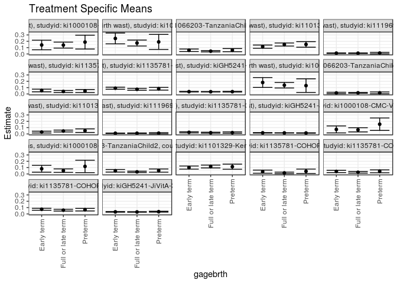

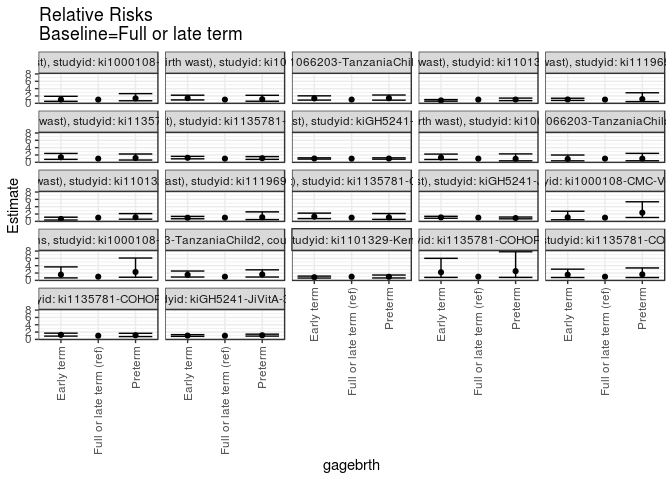

[figure not shown]

[figure not shown]

## Results Table

### Parameter: TSM

| agecat | studyid | country | intervention_level | baseline_level | estimate | ci_lower | ci_upper |
| --- | --- | --- | --- | --- | --- | --- | --- |
| 0-24 months (no birth wast) | ki1000108-CMC-V-BCS-2002 | INDIA | Full or late term | NA | 0.1398708 | 0.0928475 | 0.1868941 |
| 0-24 months (no birth wast) | ki1000108-CMC-V-BCS-2002 | INDIA | Preterm | NA | 0.1873540 | 0.0780634 | 0.2966446 |
| 0-24 months (no birth wast) | ki1000108-CMC-V-BCS-2002 | INDIA | Early term | NA | 0.1417242 | 0.0660255 | 0.2174228 |
| 0-24 months (no birth wast) | ki1000108-IRC | INDIA | Full or late term | NA | 0.1726908 | 0.1256823 | 0.2196992 |
| 0-24 months (no birth wast) | ki1000108-IRC | INDIA | Preterm | NA | 0.1904762 | 0.0715664 | 0.3093860 |
| 0-24 months (no birth wast) | ki1000108-IRC | INDIA | Early term | NA | 0.2448980 | 0.1596489 | 0.3301470 |
| 0-24 months (no birth wast) | ki1066203-TanzaniaChild2 | TANZANIA, UNITED REPUBLIC OF | Full or late term | NA | 0.0435616 | 0.0327920 | 0.0543311 |
| 0-24 months (no birth wast) | ki1066203-TanzaniaChild2 | TANZANIA, UNITED REPUBLIC OF | Preterm | NA | 0.0604206 | 0.0353644 | 0.0854767 |
| 0-24 months (no birth wast) | ki1066203-TanzaniaChild2 | TANZANIA, UNITED REPUBLIC OF | Early term | NA | 0.0579960 | 0.0379811 | 0.0780108 |
| 0-24 months (no birth wast) | ki1101329-Keneba | GAMBIA | Full or late term | NA | 0.1490265 | 0.1248115 | 0.1732415 |
| 0-24 months (no birth wast) | ki1101329-Keneba | GAMBIA | Preterm | NA | 0.1506975 | 0.1066833 | 0.1947118 |
| 0-24 months (no birth wast) | ki1101329-Keneba | GAMBIA | Early term | NA | 0.1151439 | 0.0895798 | 0.1407080 |
| 0-24 months (no birth wast) | ki1119695-PROBIT | BELARUS | Full or late term | NA | 0.0118316 | 0.0074560 | 0.0162072 |
| 0-24 months (no birth wast) | ki1119695-PROBIT | BELARUS | Preterm | NA | 0.0135364 | 0.0013326 | 0.0257401 |
| 0-24 months (no birth wast) | ki1119695-PROBIT | BELARUS | Early term | NA | 0.0122635 | 0.0085220 | 0.0160051 |
| 0-24 months (no birth wast) | ki1135781-COHORTS | INDIA | Full or late term | NA | 0.0393260 | 0.0235040 | 0.0551481 |
| 0-24 months (no birth wast) | ki1135781-COHORTS | INDIA | Preterm | NA | 0.0466401 | 0.0229696 | 0.0703106 |
| 0-24 months (no birth wast) | ki1135781-COHORTS | INDIA | Early term | NA | 0.0546064 | 0.0337514 | 0.0754613 |
| 0-24 months (no birth wast) | ki1135781-COHORTS | PHILIPPINES | Full or late term | NA | 0.0734922 | 0.0584536 | 0.0885308 |
| 0-24 months (no birth wast) | ki1135781-COHORTS | PHILIPPINES | Preterm | NA | 0.0821379 | 0.0607252 | 0.1035507 |
| 0-24 months (no birth wast) | ki1135781-COHORTS | PHILIPPINES | Early term | NA | 0.0908240 | 0.0746503 | 0.1069977 |
| 0-24 months (no birth wast) | kiGH5241-JiVitA-3 | BANGLADESH | Full or late term | NA | 0.0350287 | 0.0315271 | 0.0385302 |
| 0-24 months (no birth wast) | kiGH5241-JiVitA-3 | BANGLADESH | Preterm | NA | 0.0359858 | 0.0304846 | 0.0414870 |
| 0-24 months (no birth wast) | kiGH5241-JiVitA-3 | BANGLADESH | Early term | NA | 0.0361097 | 0.0312847 | 0.0409347 |
| 0-6 months (no birth wast) | ki1000108-IRC | INDIA | Full or late term | NA | 0.1380753 | 0.0942800 | 0.1818707 |
| 0-6 months (no birth wast) | ki1000108-IRC | INDIA | Preterm | NA | 0.1315789 | 0.0239570 | 0.2392009 |
| 0-6 months (no birth wast) | ki1000108-IRC | INDIA | Early term | NA | 0.1808511 | 0.1029377 | 0.2587645 |
| 0-6 months (no birth wast) | ki1066203-TanzaniaChild2 | TANZANIA, UNITED REPUBLIC OF | Full or late term | NA | 0.0173913 | 0.0104927 | 0.0242899 |
| 0-6 months (no birth wast) | ki1066203-TanzaniaChild2 | TANZANIA, UNITED REPUBLIC OF | Preterm | NA | 0.0174927 | 0.0036157 | 0.0313697 |
| 0-6 months (no birth wast) | ki1066203-TanzaniaChild2 | TANZANIA, UNITED REPUBLIC OF | Early term | NA | 0.0156556 | 0.0048899 | 0.0264213 |
| 0-6 months (no birth wast) | ki1101329-Keneba | GAMBIA | Full or late term | NA | 0.0461087 | 0.0312797 | 0.0609376 |
| 0-6 months (no birth wast) | ki1101329-Keneba | GAMBIA | Preterm | NA | 0.0516171 | 0.0233214 | 0.0799127 |
| 0-6 months (no birth wast) | ki1101329-Keneba | GAMBIA | Early term | NA | 0.0291928 | 0.0151451 | 0.0432405 |
| 0-6 months (no birth wast) | ki1119695-PROBIT | BELARUS | Full or late term | NA | 0.0108159 | 0.0062945 | 0.0153372 |
| 0-6 months (no birth wast) | ki1119695-PROBIT | BELARUS | Preterm | NA | 0.0120275 | 0.0028081 | 0.0212469 |
| 0-6 months (no birth wast) | ki1119695-PROBIT | BELARUS | Early term | NA | 0.0105694 | 0.0069148 | 0.0142241 |
| 0-6 months (no birth wast) | ki1135781-COHORTS | PHILIPPINES | Full or late term | NA | 0.0193063 | 0.0112615 | 0.0273511 |
| 0-6 months (no birth wast) | ki1135781-COHORTS | PHILIPPINES | Preterm | NA | 0.0206683 | 0.0093217 | 0.0320148 |
| 0-6 months (no birth wast) | ki1135781-COHORTS | PHILIPPINES | Early term | NA | 0.0250247 | 0.0161142 | 0.0339352 |
| 0-6 months (no birth wast) | kiGH5241-JiVitA-3 | BANGLADESH | Full or late term | NA | 0.0163181 | 0.0138381 | 0.0187980 |
| 0-6 months (no birth wast) | kiGH5241-JiVitA-3 | BANGLADESH | Preterm | NA | 0.0146790 | 0.0111153 | 0.0182426 |
| 0-6 months (no birth wast) | kiGH5241-JiVitA-3 | BANGLADESH | Early term | NA | 0.0175360 | 0.0141407 | 0.0209313 |
| 6-24 months | ki1000108-CMC-V-BCS-2002 | INDIA | Full or late term | NA | 0.0651163 | 0.0320891 | 0.0981435 |
| 6-24 months | ki1000108-CMC-V-BCS-2002 | INDIA | Preterm | NA | 0.1538462 | 0.0556411 | 0.2520512 |
| 6-24 months | ki1000108-CMC-V-BCS-2002 | INDIA | Early term | NA | 0.0714286 | 0.0162753 | 0.1265819 |
| 6-24 months | ki1000108-IRC | INDIA | Full or late term | NA | 0.0520000 | 0.0244424 | 0.0795576 |
| 6-24 months | ki1000108-IRC | INDIA | Preterm | NA | 0.1190476 | 0.0209818 | 0.2171134 |
| 6-24 months | ki1000108-IRC | INDIA | Early term | NA | 0.0816327 | 0.0273535 | 0.1359118 |
| 6-24 months | ki1066203-TanzaniaChild2 | TANZANIA, UNITED REPUBLIC OF | Full or late term | NA | 0.0326210 | 0.0223987 | 0.0428433 |
| 6-24 months | ki1066203-TanzaniaChild2 | TANZANIA, UNITED REPUBLIC OF | Preterm | NA | 0.0529891 | 0.0276479 | 0.0783303 |
| 6-24 months | ki1066203-TanzaniaChild2 | TANZANIA, UNITED REPUBLIC OF | Early term | NA | 0.0495213 | 0.0292339 | 0.0698086 |
| 6-24 months | ki1101329-Keneba | GAMBIA | Full or late term | NA | 0.1172759 | 0.0951152 | 0.1394366 |
| 6-24 months | ki1101329-Keneba | GAMBIA | Preterm | NA | 0.1145517 | 0.0744486 | 0.1546548 |
| 6-24 months | ki1101329-Keneba | GAMBIA | Early term | NA | 0.1007301 | 0.0763119 | 0.1251484 |
| 6-24 months | ki1135781-COHORTS | GUATEMALA | Full or late term | NA | 0.0163934 | 0.0043414 | 0.0284455 |
| 6-24 months | ki1135781-COHORTS | GUATEMALA | Preterm | NA | 0.0413223 | 0.0058355 | 0.0768091 |
| 6-24 months | ki1135781-COHORTS | GUATEMALA | Early term | NA | 0.0361991 | 0.0115570 | 0.0608412 |
| 6-24 months | ki1135781-COHORTS | INDIA | Full or late term | NA | 0.0256859 | 0.0127118 | 0.0386601 |
| 6-24 months | ki1135781-COHORTS | INDIA | Preterm | NA | 0.0416061 | 0.0190428 | 0.0641694 |
| 6-24 months | ki1135781-COHORTS | INDIA | Early term | NA | 0.0398272 | 0.0216958 | 0.0579586 |
| 6-24 months | ki1135781-COHORTS | PHILIPPINES | Full or late term | NA | 0.0593037 | 0.0451427 | 0.0734646 |
| 6-24 months | ki1135781-COHORTS | PHILIPPINES | Preterm | NA | 0.0671854 | 0.0469896 | 0.0873812 |
| 6-24 months | ki1135781-COHORTS | PHILIPPINES | Early term | NA | 0.0735812 | 0.0583567 | 0.0888058 |
| 6-24 months | kiGH5241-JiVitA-3 | BANGLADESH | Full or late term | NA | 0.0309309 | 0.0267062 | 0.0351557 |
| 6-24 months | kiGH5241-JiVitA-3 | BANGLADESH | Preterm | NA | 0.0350108 | 0.0281306 | 0.0418911 |
| 6-24 months | kiGH5241-JiVitA-3 | BANGLADESH | Early term | NA | 0.0323362 | 0.0268233 | 0.0378490 |

### Parameter: E(Y)

| agecat | studyid | country | intervention_level | baseline_level | estimate | ci_lower | ci_upper |
| --- | --- | --- | --- | --- | --- | --- | --- |
| 0-24 months (no birth wast) | ki1000108-CMC-V-BCS-2002 | INDIA | NA | NA | 0.1494253 | 0.1119149 | 0.1869357 |
| 0-24 months (no birth wast) | ki1000108-IRC | INDIA | NA | NA | 0.1928021 | 0.1535486 | 0.2320555 |
| 0-24 months (no birth wast) | ki1066203-TanzaniaChild2 | TANZANIA, UNITED REPUBLIC OF | NA | NA | 0.0495094 | 0.0405280 | 0.0584908 |
| 0-24 months (no birth wast) | ki1101329-Keneba | GAMBIA | NA | NA | 0.1377069 | 0.1212828 | 0.1541310 |
| 0-24 months (no birth wast) | ki1119695-PROBIT | BELARUS | NA | NA | 0.0120875 | 0.0084025 | 0.0157724 |
| 0-24 months (no birth wast) | ki1135781-COHORTS | INDIA | NA | NA | 0.0460967 | 0.0348859 | 0.0573074 |
| 0-24 months (no birth wast) | ki1135781-COHORTS | PHILIPPINES | NA | NA | 0.0821918 | 0.0723504 | 0.0920332 |
| 0-24 months (no birth wast) | kiGH5241-JiVitA-3 | BANGLADESH | NA | NA | 0.0357002 | 0.0330794 | 0.0383209 |
| 0-6 months (no birth wast) | ki1000108-IRC | INDIA | NA | NA | 0.1482480 | 0.1120405 | 0.1844555 |
| 0-6 months (no birth wast) | ki1066203-TanzaniaChild2 | TANZANIA, UNITED REPUBLIC OF | NA | NA | 0.0170098 | 0.0116466 | 0.0223731 |
| 0-6 months (no birth wast) | ki1101329-Keneba | GAMBIA | NA | NA | 0.0408946 | 0.0310794 | 0.0507097 |
| 0-6 months (no birth wast) | ki1119695-PROBIT | BELARUS | NA | NA | 0.0107462 | 0.0070475 | 0.0144449 |
| 0-6 months (no birth wast) | ki1135781-COHORTS | PHILIPPINES | NA | NA | 0.0218708 | 0.0166115 | 0.0271301 |
| 0-6 months (no birth wast) | kiGH5241-JiVitA-3 | BANGLADESH | NA | NA | 0.0164098 | 0.0145698 | 0.0182498 |
| 6-24 months | ki1000108-CMC-V-BCS-2002 | INDIA | NA | NA | 0.0797721 | 0.0513872 | 0.1081570 |
| 6-24 months | ki1000108-IRC | INDIA | NA | NA | 0.0666667 | 0.0418784 | 0.0914549 |
| 6-24 months | ki1066203-TanzaniaChild2 | TANZANIA, UNITED REPUBLIC OF | NA | NA | 0.0400633 | 0.0312360 | 0.0488905 |
| 6-24 months | ki1101329-Keneba | GAMBIA | NA | NA | 0.1107034 | 0.0954900 | 0.1259167 |
| 6-24 months | ki1135781-COHORTS | GUATEMALA | NA | NA | 0.0260078 | 0.0147515 | 0.0372641 |
| 6-24 months | ki1135781-COHORTS | INDIA | NA | NA | 0.0339111 | 0.0241689 | 0.0436532 |
| 6-24 months | ki1135781-COHORTS | PHILIPPINES | NA | NA | 0.0667384 | 0.0574713 | 0.0760056 |
| 6-24 months | kiGH5241-JiVitA-3 | BANGLADESH | NA | NA | 0.0322267 | 0.0291993 | 0.0352542 |

### Parameter: RR

| agecat | studyid | country | intervention_level | baseline_level | estimate | ci_lower | ci_upper |
| --- | --- | --- | --- | --- | --- | --- | --- |
| 0-24 months (no birth wast) | ki1000108-CMC-V-BCS-2002 | INDIA | Full or late term | Full or late term | 1.0000000 | 1.0000000 | 1.000000 |
| 0-24 months (no birth wast) | ki1000108-CMC-V-BCS-2002 | INDIA | Preterm | Full or late term | 1.3394794 | 0.6820191 | 2.630726 |
| 0-24 months (no birth wast) | ki1000108-CMC-V-BCS-2002 | INDIA | Early term | Full or late term | 1.0132507 | 0.5389076 | 1.905108 |
| 0-24 months (no birth wast) | ki1000108-IRC | INDIA | Full or late term | Full or late term | 1.0000000 | 1.0000000 | 1.000000 |
| 0-24 months (no birth wast) | ki1000108-IRC | INDIA | Preterm | Full or late term | 1.1029900 | 0.5582108 | 2.179440 |
| 0-24 months (no birth wast) | ki1000108-IRC | INDIA | Early term | Full or late term | 1.4181300 | 0.9115965 | 2.206122 |
| 0-24 months (no birth wast) | ki1066203-TanzaniaChild2 | TANZANIA, UNITED REPUBLIC OF | Full or late term | Full or late term | 1.0000000 | 1.0000000 | 1.000000 |
| 0-24 months (no birth wast) | ki1066203-TanzaniaChild2 | TANZANIA, UNITED REPUBLIC OF | Preterm | Full or late term | 1.3870163 | 0.8558829 | 2.247754 |
| 0-24 months (no birth wast) | ki1066203-TanzaniaChild2 | TANZANIA, UNITED REPUBLIC OF | Early term | Full or late term | 1.3313566 | 0.8707998 | 2.035497 |
| 0-24 months (no birth wast) | ki1101329-Keneba | GAMBIA | Full or late term | Full or late term | 1.0000000 | 1.0000000 | 1.000000 |
| 0-24 months (no birth wast) | ki1101329-Keneba | GAMBIA | Preterm | Full or late term | 1.0112128 | 0.7240308 | 1.412303 |
| 0-24 months (no birth wast) | ki1101329-Keneba | GAMBIA | Early term | Full or late term | 0.7726402 | 0.5871081 | 1.016802 |
| 0-24 months (no birth wast) | ki1119695-PROBIT | BELARUS | Full or late term | Full or late term | 1.0000000 | 1.0000000 | 1.000000 |
| 0-24 months (no birth wast) | ki1119695-PROBIT | BELARUS | Preterm | Full or late term | 1.1440894 | 0.4554164 | 2.874162 |
| 0-24 months (no birth wast) | ki1119695-PROBIT | BELARUS | Early term | Full or late term | 1.0365092 | 0.7781711 | 1.380611 |
| 0-24 months (no birth wast) | ki1135781-COHORTS | INDIA | Full or late term | Full or late term | 1.0000000 | 1.0000000 | 1.000000 |
| 0-24 months (no birth wast) | ki1135781-COHORTS | INDIA | Preterm | Full or late term | 1.1859848 | 0.6206532 | 2.266257 |
| 0-24 months (no birth wast) | ki1135781-COHORTS | INDIA | Early term | Full or late term | 1.3885548 | 0.7974655 | 2.417765 |
| 0-24 months (no birth wast) | ki1135781-COHORTS | PHILIPPINES | Full or late term | Full or late term | 1.0000000 | 1.0000000 | 1.000000 |
| 0-24 months (no birth wast) | ki1135781-COHORTS | PHILIPPINES | Preterm | Full or late term | 1.1176415 | 0.8023538 | 1.556823 |
| 0-24 months (no birth wast) | ki1135781-COHORTS | PHILIPPINES | Early term | Full or late term | 1.2358323 | 0.9424723 | 1.620505 |
| 0-24 months (no birth wast) | kiGH5241-JiVitA-3 | BANGLADESH | Full or late term | Full or late term | 1.0000000 | 1.0000000 | 1.000000 |
| 0-24 months (no birth wast) | kiGH5241-JiVitA-3 | BANGLADESH | Preterm | Full or late term | 1.0273252 | 0.8604206 | 1.226606 |
| 0-24 months (no birth wast) | kiGH5241-JiVitA-3 | BANGLADESH | Early term | Full or late term | 1.0308610 | 0.8755230 | 1.213759 |
| 0-6 months (no birth wast) | ki1000108-IRC | INDIA | Full or late term | Full or late term | 1.0000000 | 1.0000000 | 1.000000 |
| 0-6 months (no birth wast) | ki1000108-IRC | INDIA | Preterm | Full or late term | 0.9529506 | 0.3963465 | 2.291214 |
| 0-6 months (no birth wast) | ki1000108-IRC | INDIA | Early term | Full or late term | 1.3098001 | 0.7671220 | 2.236380 |
| 0-6 months (no birth wast) | ki1066203-TanzaniaChild2 | TANZANIA, UNITED REPUBLIC OF | Full or late term | Full or late term | 1.0000000 | 1.0000000 | 1.000000 |
| 0-6 months (no birth wast) | ki1066203-TanzaniaChild2 | TANZANIA, UNITED REPUBLIC OF | Preterm | Full or late term | 1.0058309 | 0.4143137 | 2.441859 |
| 0-6 months (no birth wast) | ki1066203-TanzaniaChild2 | TANZANIA, UNITED REPUBLIC OF | Early term | Full or late term | 0.9001957 | 0.4069725 | 1.991172 |
| 0-6 months (no birth wast) | ki1101329-Keneba | GAMBIA | Full or late term | Full or late term | 1.0000000 | 1.0000000 | 1.000000 |
| 0-6 months (no birth wast) | ki1101329-Keneba | GAMBIA | Preterm | Full or late term | 1.1194656 | 0.5929871 | 2.113373 |
| 0-6 months (no birth wast) | ki1101329-Keneba | GAMBIA | Early term | Full or late term | 0.6331300 | 0.3550165 | 1.129113 |
| 0-6 months (no birth wast) | ki1119695-PROBIT | BELARUS | Full or late term | Full or late term | 1.0000000 | 1.0000000 | 1.000000 |
| 0-6 months (no birth wast) | ki1119695-PROBIT | BELARUS | Preterm | Full or late term | 1.1120200 | 0.4780743 | 2.586603 |
| 0-6 months (no birth wast) | ki1119695-PROBIT | BELARUS | Early term | Full or late term | 0.9772125 | 0.7081553 | 1.348496 |
| 0-6 months (no birth wast) | ki1135781-COHORTS | PHILIPPINES | Full or late term | Full or late term | 1.0000000 | 1.0000000 | 1.000000 |
| 0-6 months (no birth wast) | ki1135781-COHORTS | PHILIPPINES | Preterm | Full or late term | 1.0705441 | 0.5373948 | 2.132631 |
| 0-6 months (no birth wast) | ki1135781-COHORTS | PHILIPPINES | Early term | Full or late term | 1.2961913 | 0.7491939 | 2.242560 |
| 0-6 months (no birth wast) | kiGH5241-JiVitA-3 | BANGLADESH | Full or late term | Full or late term | 1.0000000 | 1.0000000 | 1.000000 |
| 0-6 months (no birth wast) | kiGH5241-JiVitA-3 | BANGLADESH | Preterm | Full or late term | 0.8995535 | 0.6860180 | 1.179556 |
| 0-6 months (no birth wast) | kiGH5241-JiVitA-3 | BANGLADESH | Early term | Full or late term | 1.0746384 | 0.8424309 | 1.370851 |
| 6-24 months | ki1000108-CMC-V-BCS-2002 | INDIA | Full or late term | Full or late term | 1.0000000 | 1.0000000 | 1.000000 |
| 6-24 months | ki1000108-CMC-V-BCS-2002 | INDIA | Preterm | Full or late term | 2.3626374 | 1.0454758 | 5.339249 |
| 6-24 months | ki1000108-CMC-V-BCS-2002 | INDIA | Early term | Full or late term | 1.0969388 | 0.4354790 | 2.763106 |
| 6-24 months | ki1000108-IRC | INDIA | Full or late term | Full or late term | 1.0000000 | 1.0000000 | 1.000000 |
| 6-24 months | ki1000108-IRC | INDIA | Preterm | Full or late term | 2.2893773 | 0.8596588 | 6.096894 |
| 6-24 months | ki1000108-IRC | INDIA | Early term | Full or late term | 1.5698587 | 0.6707962 | 3.673927 |
| 6-24 months | ki1066203-TanzaniaChild2 | TANZANIA, UNITED REPUBLIC OF | Full or late term | Full or late term | 1.0000000 | 1.0000000 | 1.000000 |
| 6-24 months | ki1066203-TanzaniaChild2 | TANZANIA, UNITED REPUBLIC OF | Preterm | Full or late term | 1.6243864 | 0.9171092 | 2.877118 |
| 6-24 months | ki1066203-TanzaniaChild2 | TANZANIA, UNITED REPUBLIC OF | Early term | Full or late term | 1.5180793 | 0.9059505 | 2.543809 |
| 6-24 months | ki1101329-Keneba | GAMBIA | Full or late term | Full or late term | 1.0000000 | 1.0000000 | 1.000000 |
| 6-24 months | ki1101329-Keneba | GAMBIA | Preterm | Full or late term | 0.9767708 | 0.6563094 | 1.453706 |
| 6-24 months | ki1101329-Keneba | GAMBIA | Early term | Full or late term | 0.8589156 | 0.6318392 | 1.167601 |
| 6-24 months | ki1135781-COHORTS | GUATEMALA | Full or late term | Full or late term | 1.0000000 | 1.0000000 | 1.000000 |
| 6-24 months | ki1135781-COHORTS | GUATEMALA | Preterm | Full or late term | 2.5206609 | 0.8138650 | 7.806862 |
| 6-24 months | ki1135781-COHORTS | GUATEMALA | Early term | Full or late term | 2.2081446 | 0.8107545 | 6.014031 |
| 6-24 months | ki1135781-COHORTS | INDIA | Full or late term | Full or late term | 1.0000000 | 1.0000000 | 1.000000 |
| 6-24 months | ki1135781-COHORTS | INDIA | Preterm | Full or late term | 1.6198011 | 0.7726233 | 3.395905 |
| 6-24 months | ki1135781-COHORTS | INDIA | Early term | Full or late term | 1.5505447 | 0.7857855 | 3.059599 |
| 6-24 months | ki1135781-COHORTS | PHILIPPINES | Full or late term | Full or late term | 1.0000000 | 1.0000000 | 1.000000 |
| 6-24 months | ki1135781-COHORTS | PHILIPPINES | Preterm | Full or late term | 1.1329054 | 0.7719871 | 1.662560 |
| 6-24 months | ki1135781-COHORTS | PHILIPPINES | Early term | Full or late term | 1.2407538 | 0.9050346 | 1.701007 |
| 6-24 months | kiGH5241-JiVitA-3 | BANGLADESH | Full or late term | Full or late term | 1.0000000 | 1.0000000 | 1.000000 |
| 6-24 months | kiGH5241-JiVitA-3 | BANGLADESH | Preterm | Full or late term | 1.1319049 | 0.8949650 | 1.431574 |
| 6-24 months | kiGH5241-JiVitA-3 | BANGLADESH | Early term | Full or late term | 1.0454326 | 0.8376829 | 1.304705 |

### Parameter: PAR

| agecat | studyid | country | intervention_level | baseline_level | estimate | ci_lower | ci_upper |
| --- | --- | --- | --- | --- | --- | --- | --- |
| 0-24 months (no birth wast) | ki1000108-CMC-V-BCS-2002 | INDIA | Full or late term | NA | 0.0095545 | -0.0209702 | 0.0400792 |
| 0-24 months (no birth wast) | ki1000108-IRC | INDIA | Full or late term | NA | 0.0201113 | -0.0102472 | 0.0504698 |
| 0-24 months (no birth wast) | ki1066203-TanzaniaChild2 | TANZANIA, UNITED REPUBLIC OF | Full or late term | NA | 0.0059478 | -0.0014055 | 0.0133011 |
| 0-24 months (no birth wast) | ki1101329-Keneba | GAMBIA | Full or late term | NA | -0.0113197 | -0.0278491 | 0.0052098 |
| 0-24 months (no birth wast) | ki1119695-PROBIT | BELARUS | Full or late term | NA | 0.0002559 | -0.0014408 | 0.0019526 |
| 0-24 months (no birth wast) | ki1135781-COHORTS | INDIA | Full or late term | NA | 0.0067706 | -0.0058467 | 0.0193880 |
| 0-24 months (no birth wast) | ki1135781-COHORTS | PHILIPPINES | Full or late term | NA | 0.0086996 | -0.0034475 | 0.0208466 |
| 0-24 months (no birth wast) | kiGH5241-JiVitA-3 | BANGLADESH | Full or late term | NA | 0.0006715 | -0.0016764 | 0.0030194 |
| 0-6 months (no birth wast) | ki1000108-IRC | INDIA | Full or late term | NA | 0.0101727 | -0.0173555 | 0.0377009 |
| 0-6 months (no birth wast) | ki1066203-TanzaniaChild2 | TANZANIA, UNITED REPUBLIC OF | Full or late term | NA | -0.0003815 | -0.0045718 | 0.0038089 |
| 0-6 months (no birth wast) | ki1101329-Keneba | GAMBIA | Full or late term | NA | -0.0052141 | -0.0151462 | 0.0047180 |
| 0-6 months (no birth wast) | ki1119695-PROBIT | BELARUS | Full or late term | NA | -0.0000697 | -0.0018367 | 0.0016974 |
| 0-6 months (no birth wast) | ki1135781-COHORTS | PHILIPPINES | Full or late term | NA | 0.0025645 | -0.0040134 | 0.0091424 |
| 0-6 months (no birth wast) | kiGH5241-JiVitA-3 | BANGLADESH | Full or late term | NA | 0.0000918 | -0.0015350 | 0.0017185 |
| 6-24 months | ki1000108-CMC-V-BCS-2002 | INDIA | Full or late term | NA | 0.0146558 | -0.0090126 | 0.0383242 |
| 6-24 months | ki1000108-IRC | INDIA | Full or late term | NA | 0.0146667 | -0.0053399 | 0.0346732 |
| 6-24 months | ki1066203-TanzaniaChild2 | TANZANIA, UNITED REPUBLIC OF | Full or late term | NA | 0.0074423 | 0.0000625 | 0.0148220 |
| 6-24 months | ki1101329-Keneba | GAMBIA | Full or late term | NA | -0.0065726 | -0.0218454 | 0.0087003 |
| 6-24 months | ki1135781-COHORTS | GUATEMALA | Full or late term | NA | 0.0096144 | -0.0009047 | 0.0201334 |
| 6-24 months | ki1135781-COHORTS | INDIA | Full or late term | NA | 0.0082251 | -0.0025610 | 0.0190113 |
| 6-24 months | ki1135781-COHORTS | PHILIPPINES | Full or late term | NA | 0.0074348 | -0.0039739 | 0.0188434 |
| 6-24 months | kiGH5241-JiVitA-3 | BANGLADESH | Full or late term | NA | 0.0012958 | -0.0015743 | 0.0041659 |

### Parameter: PAF

| agecat | studyid | country | intervention_level | baseline_level | estimate | ci_lower | ci_upper |
| --- | --- | --- | --- | --- | --- | --- | --- |
| 0-24 months (no birth wast) | ki1000108-CMC-V-BCS-2002 | INDIA | Full or late term | NA | 0.0639418 | -0.1640151 | 0.2472563 |
| 0-24 months (no birth wast) | ki1000108-IRC | INDIA | Full or late term | NA | 0.1043106 | -0.0668583 | 0.2480168 |
| 0-24 months (no birth wast) | ki1066203-TanzaniaChild2 | TANZANIA, UNITED REPUBLIC OF | Full or late term | NA | 0.1201350 | -0.0398816 | 0.2555284 |
| 0-24 months (no birth wast) | ki1101329-Keneba | GAMBIA | Full or late term | NA | -0.0822012 | -0.2087161 | 0.0310714 |
| 0-24 months (no birth wast) | ki1119695-PROBIT | BELARUS | Full or late term | NA | 0.0211692 | -0.1315283 | 0.1532605 |
| 0-24 months (no birth wast) | ki1135781-COHORTS | INDIA | Full or late term | NA | 0.1468787 | -0.1730375 | 0.3795459 |
| 0-24 months (no birth wast) | ki1135781-COHORTS | PHILIPPINES | Full or late term | NA | 0.1058448 | -0.0543591 | 0.2417066 |
| 0-24 months (no birth wast) | kiGH5241-JiVitA-3 | BANGLADESH | Full or late term | NA | 0.0188094 | -0.0492121 | 0.0824210 |
| 0-6 months (no birth wast) | ki1000108-IRC | INDIA | Full or late term | NA | 0.0686192 | -0.1362511 | 0.2365507 |
| 0-6 months (no birth wast) | ki1066203-TanzaniaChild2 | TANZANIA, UNITED REPUBLIC OF | Full or late term | NA | -0.0224256 | -0.3008630 | 0.1964149 |
| 0-6 months (no birth wast) | ki1101329-Keneba | GAMBIA | Full or late term | NA | -0.1275013 | -0.3960480 | 0.0893872 |
| 0-6 months (no birth wast) | ki1119695-PROBIT | BELARUS | Full or late term | NA | -0.0064824 | -0.1843989 | 0.1447080 |
| 0-6 months (no birth wast) | ki1135781-COHORTS | PHILIPPINES | Full or late term | NA | 0.1172558 | -0.2393927 | 0.3712749 |
| 0-6 months (no birth wast) | kiGH5241-JiVitA-3 | BANGLADESH | Full or late term | NA | 0.0055935 | -0.0986646 | 0.0999579 |
| 6-24 months | ki1000108-CMC-V-BCS-2002 | INDIA | Full or late term | NA | 0.1837209 | -0.1651221 | 0.4281187 |
| 6-24 months | ki1000108-IRC | INDIA | Full or late term | NA | 0.2200000 | -0.1312945 | 0.4622090 |
| 6-24 months | ki1066203-TanzaniaChild2 | TANZANIA, UNITED REPUBLIC OF | Full or late term | NA | 0.1857628 | -0.0156102 | 0.3472080 |
| 6-24 months | ki1101329-Keneba | GAMBIA | Full or late term | NA | -0.0593710 | -0.2064665 | 0.0697902 |
| 6-24 months | ki1135781-COHORTS | GUATEMALA | Full or late term | NA | 0.3696721 | -0.1384210 | 0.6509962 |
| 6-24 months | ki1135781-COHORTS | INDIA | Full or late term | NA | 0.2425500 | -0.1426190 | 0.4978812 |
| 6-24 months | ki1135781-COHORTS | PHILIPPINES | Full or late term | NA | 0.1114017 | -0.0765674 | 0.2665514 |
| 6-24 months | kiGH5241-JiVitA-3 | BANGLADESH | Full or late term | NA | 0.0402098 | -0.0533064 | 0.1254232 |